# DATA606 - Inference for Numerical Data

October 14, 2020

## Announcements

- If you haven’t already, complete the Census by this Friday: https://www.census.gov
- American Statistical Association released a statement on p-values: http://amstat.tandfonline.com/doi/abs/10.1080/00031305.2016.1154108
- Retire Statistical Significance: The discussion: From Andrew Gelman’s blog: https://statmodeling.stat.columbia.edu/2019/03/20/retire-statistical-significance-the-discussion/

## Meetup Presentations

- 5.3 - [Karim Hammoud](https://rpubs.com/karim7mod/675840)
- 5.5 - [Gehad Gad](https://rpubs.com/GehadGad/675805)
- 5.7 - [Evan McLaughlin](https://rpubs.com/mclaueva/675597)

## High School & Beyond Survey

200 randomly selected students completed the reading and writing test of the High School and Beyond survey. The results appear to the right. Does there appear to be a difference?

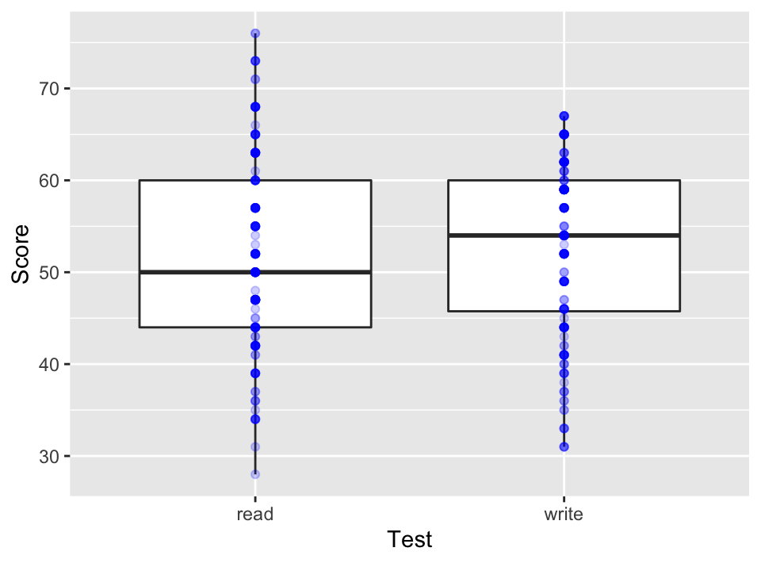

```r
data(hsb2) # in openintro package
hsb2.melt <- melt(hsb2[,c('id','read', 'write')], id='id')
ggplot(hsb2.melt, aes(x=variable, y=value)) +   geom_boxplot() +
    geom_point(alpha=0.2, color='blue') + xlab('Test') + ylab('Score')
```

## High School & Beyond Survey

```r
head(hsb2)
```

```
## # A tibble: 6 x 11
##      id gender race  ses    schtyp prog        read write  math science socst
##   <int> <chr>  <chr> <fct>  <fct>  <fct>      <int> <int> <int>   <int> <int>
## 1    70 male   white low    public general       57    52    41      47    57
## 2   121 female white middle public vocational    68    59    53      63    61
## 3    86 male   white high   public general       44    33    54      58    31
## 4   141 male   white high   public vocational    63    44    47      53    56
## 5   172 male   white middle public academic      47    52    57      53    61
## 6   113 male   white middle public academic      44    52    51      63    61
```

Are the reading and writing scores of each student independent of each other?

## Analyzing Paired Data

- When two sets of observations are not independent, they are said to be paired.
- To analyze these type of data, we often look at the difference.

```r
hsb2$diff <- hsb2$read - hsb2$write
head(hsb2$diff)
```

```
## [1]  5  9 11 19 -5 -8
```

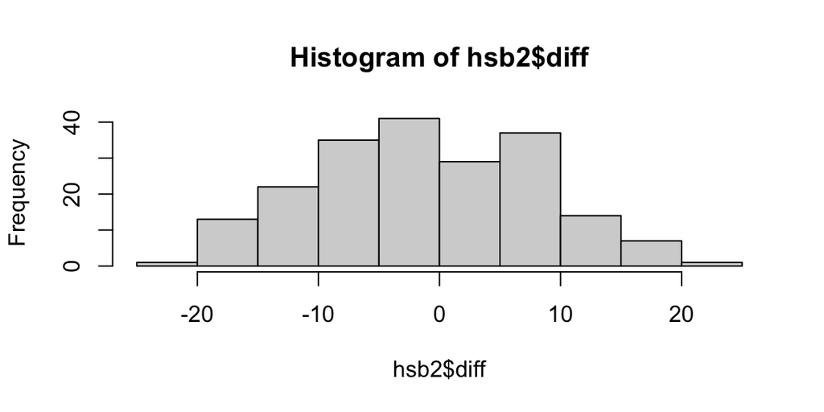

```r
hist(hsb2$diff)
```

## Setting the Hypothesis

What are the hypothesis for testing if there is a difference between the average reading and writing scores?

\(H_0\): There is no difference between the average reading and writing scores.

\[\mu_{diff} = 0\]

\(H_A\): There is a difference between the average reading and writing score.

\[\mu_{diff} \ne 0\]

## Nothing new here…

- The analysis is no different that what we have done before.
- We have data from one sample: differences.
- We are testing to see if the average difference is different that 0.

## Calculating the test-statistic and the p-value

The observed average difference between the two scores is -0.545 points and the standard deviation of the difference is 8.8866664 points. Do these data provide confincing evidence of a difference between the average scores ont eh two exams (use \(\alpha = 0.05\))?

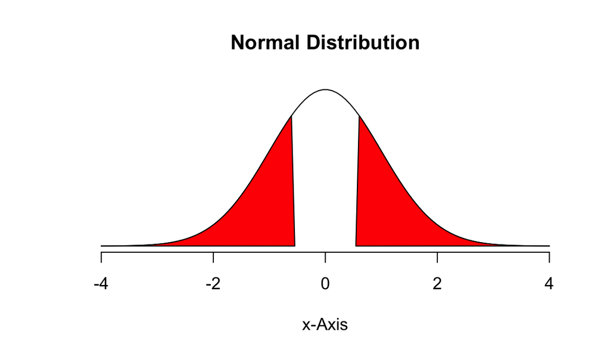

## Calculating the test-statistic and the p-value

\[Z = \frac{-0.545 - 0}{ \frac{8.887}{\sqrt{200}} } = \frac{-0.545}{0.628} = -0.87\] \[p-value = 0.1949 \times 2 = 0.3898\]

Since p-value > 0.05, we fail to reject the null hypothesis. That is, the data do not provide evidence that there is a statistically significant difference between the average reading and writing scores.

```r
2 * pnorm(mean(hsb2$diff), mean=0, sd=sd(hsb2$diff)/sqrt(nrow(hsb2)))
```

```
## [1] 0.3857741
```

## Interpretation of the p-value

The probability of obtaining a random sample of 200 students where the average difference between the reading and writing scores is at least 0.545 (in either direction), if in fact the true average difference between the score is 0, is 38%.

## Calculating 95% Confidence Interval

\[-0.545\pm 1.96\frac { 8.887 }{ \sqrt { 200 } } =-0.545\pm 1.96\times 0.628=(-1.775, 0.685)\]

Note that the confidence interval spans zero!

## SAT Scores by Gender

```r
data(sat)
head(sat)
```

```
##   Verbal.SAT Math.SAT Sex
## 1        450      450   F
## 2        640      540   F
## 3        590      570   M
## 4        400      400   M
## 5        600      590   M
## 6        610      610   M
```

Is there a difference in math scores between males and females?

## SAT Scores by Gender

```r
describeBy(sat$Math.SAT, group=sat$Sex, mat=TRUE, skew=FALSE)[,c(2,4:7)]
```

```
##     group1  n     mean        sd min
## X11      F 82 597.6829 103.70065 360
## X12      M 80 626.8750  90.35225 390
```

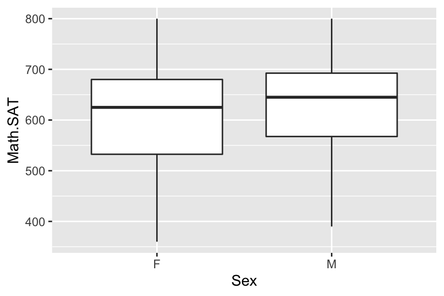

```r
ggplot(sat, aes(x=Sex, y=Math.SAT)) + geom_boxplot()
```

## Distributions

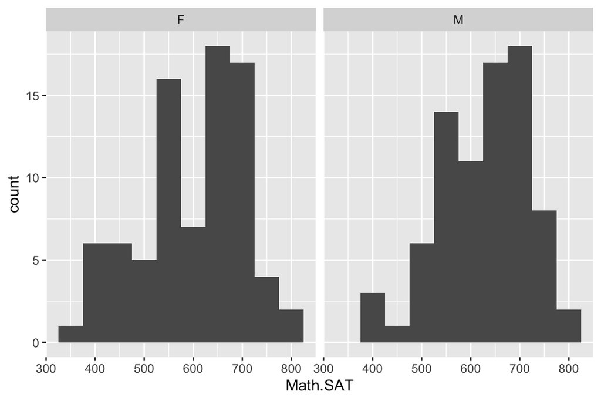

```r
ggplot(sat, aes(x=Math.SAT)) + geom_histogram(binwidth=50) + facet_wrap(~ Sex)
```

## 95% Confidence Interval

We wish to calculate a 95% confidence interval for the average difference between SAT scores for males and females.

Assumptions:

1. Independence within groups.
2. Independence between groups.
3. Sample size/skew

## Confidence Interval for Difference Between Two Means

Standard error of the difference between two sample means

\[ SE_{ (\bar { x } _{ 1 }-\bar { x } _{ 2 }) }=\sqrt { \frac { { s }_{ 1 }^{ 2 } }{ { n }_{ 1 } } +\frac { { s }_{ 2 }^{ 2 } }{ { n }_{ 2 } } } \]

## Student’s *t*-Distribution

What if you want to compare the quality of one batch of Guinness beer to the next?

- Sample sizes necessarily need to be small.
- The CLT states that the sampling distribution approximates normal as n -> Infinity
- Need an alternative to the normal distribution.
- The *t* distribution was developed by William Gosset (under the pseudonym *student*) to estimate means when the sample size is small.

Confidence interval is estimated using

\[\overline { x } \pm { t }_{ df }^{ * }SE\]

Where *df* is the degrees of freedom (*df* = *n* -1)

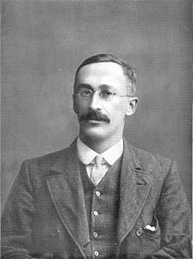

## *t*-Distributions

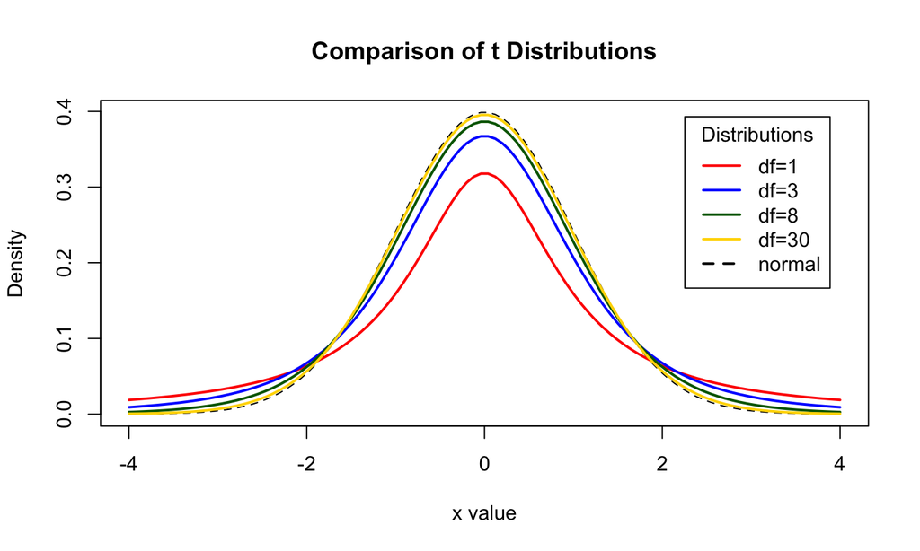

## *t*-test in R

The `pt` and `qt` will give you the *p*-value and critical value from the *t*-distribution, respectively.

Critical value for p = 0.05, degrees of freedom = 10

```r
qt(0.025, df = 10)
```

```
## [1] -2.228139
```

p-value for a critical value of 2, degrees of freedom = 10

```r
pt(2, df=10)
```

```
## [1] 0.963306
```

The `t.test` function will calculate a null hyphothesis test using the *t*-distribution.

```r
t.test(Math.SAT ~ Sex, data = sat)
```

```
##
##  Welch Two Sample t-test
##
## data:  Math.SAT by Sex
## t = -1.9117, df = 158.01, p-value = 0.05773
## alternative hypothesis: true difference in means is not equal to 0
## 95 percent confidence interval:
##  -59.3527145   0.9685682
## sample estimates:
## mean in group F mean in group M
##        597.6829        626.8750
```

## Analysis of Variance (ANOVA)

The goal of ANOVA is to test whether there is a discernible difference between the means of several groups.

#### Example

- Each tested with 8 replications
- Treatments randomly assigned

For ANOVA:

- The means all differ.
- Is this just natural variability?
- Null hypothesis: All the means are the same.
- Alternative hypothesis: The means are not all the same.

## Hand Washing Comparison

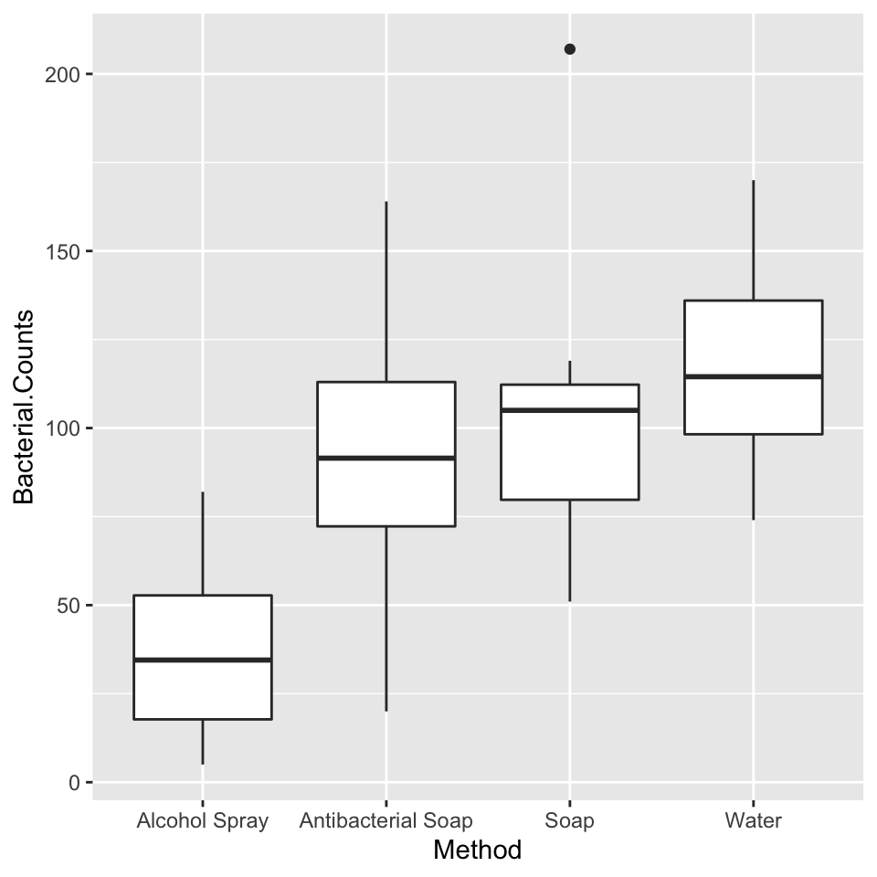

```r
ggplot(hand, aes(x=Method, y=Bacterial.Counts)) + geom_boxplot()
```

## Hand Washing Comparison (cont.)

```r
desc <- describeBy(hand$Bacterial.Counts, hand$Method, mat=TRUE)[,c(2,4,5,6)]
desc$Var <- desc$sd^2
print(desc, row.names=FALSE)
```

```
##              group1 n  mean       sd       Var
##       Alcohol Spray 8  37.5 26.55991  705.4286
##  Antibacterial Soap 8  92.5 41.96257 1760.8571
##                Soap 8 106.0 46.95895 2205.1429
##               Water 8 117.0 31.13106  969.1429
```

## Washing type all the same?

- \(H_0: \mu_1 = \mu_2 = \mu_3 = \mu_4\)
- By Central Limit Theorem:  
  \[ Var(\bar{y}) = \frac{\sigma^2}{n} = \frac{\sigma^2}{8} \]
- Variance of {37.5, 92.5, 106.0, 117.0} is 1245.08.
- \(\frac{\sigma^2}{8} = 1245.08\)
- \(\sigma^2 = 9960.64\)
- This estimate for \(\sigma^2\) is called the Treatment Mean Square, Between Mean Square, or \(MS_T\)
- Is this very high compared to what we would expect?

## Comparing \(MS_T\) (between) and \(MS_E\) (within)

\(MS_T\)

- Estimates \(s^2\) if \(H_0\) is true
- Should be larger than \(s^2\) if \(H_0\) is false

\(MS_E\)

- Estimates \(s^2\) whether \(H_0\) is true or not
- If \(H_0\) is true, both close to \(s^2\), so \(MS_T\) is close to \(MS_E\)

Comparing

- If \(H_0\) is true, \(\frac{MS_T}{MS_E}\) should be close to 1
- If \(H_0\) is false, \(\frac{MS_T}{MS_E}\) tends to be > 1

## The F-Distribution

- How do we tell whether \(\frac{MS_T}{MS_E}\) is larger enough to not be due just to random chance
- \(\frac{MS_T}{MS_E}\) follows the F-Distribution
  - Numerator df: k - 1 (k = number of groups)
  - Denominator df: k(n - 1)
  - n = # observations in each group
- \(F = \frac{MS_T}{MS_E}\) is called the F-Statistic.

A Shiny App by Dr. Dudek to explore the F-Distribution: https://shiny.rit.albany.edu/stat/fdist/

## The F-Distribution (cont.)

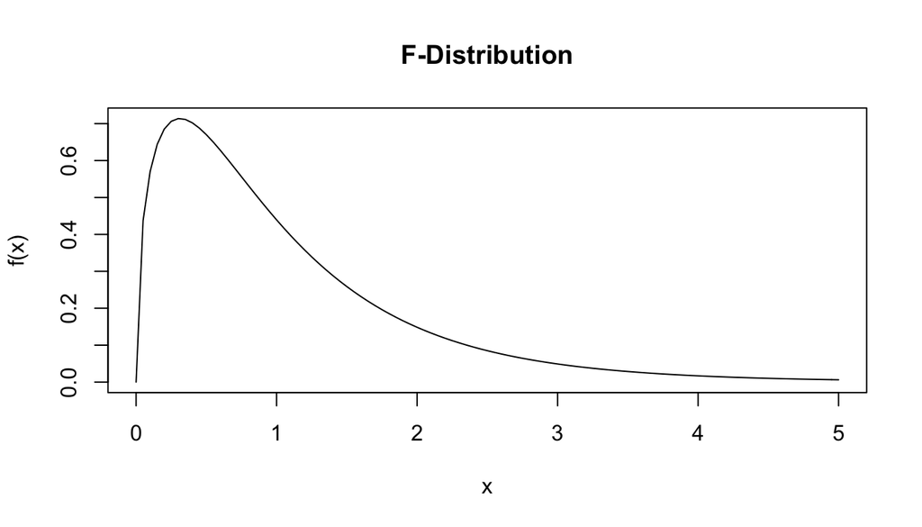

```r
df.numerator <- 4 - 1
df.denominator <- 4 * (8 - 1)
plot(function(x)(df(x,df1=df.numerator,df2=df.denominator)),
     xlim=c(0,5), xlab='x', ylab='f(x)', main='F-Distribution')
```

## Back to Bacteria

- \(MS_T = 9960.64\)
- \(MS_E = 1410.14\)
- Numerator df = 4 - 1 = 3
- Denominator df = 4(8 - 1) = 28.

```r
(f.stat <- 9960.64 / 1410.14)
```

```
## [1] 7.063582
```

```r
1 - pf(f.stat, 3, 28)
```

```
## [1] 0.001111464
```

#### P-value for \(F_{3,28} = 0.0011\)

## Assumptions and Conditions

- To check the assumptions and conditions for ANOVA, always look at the side-by-side boxplots.
  - Check for outliers within any group.
  - Check for similar spreads.
  - Look for skewness.
  - Consider re-expressing.
- Independence Assumption
  - Groups must be independent of each other.
  - Data within each group must be independent.
  - Randomization Condition
- Equal Variance Assumption
  - In ANOVA, we pool the variances. This requires equal variances from each group: Similar Spread Condition.

## ANOVA in R

```r
aov.out <- aov(Bacterial.Counts ~ Method, data=hand)
summary(aov.out)
```

```
##             Df Sum Sq Mean Sq F value  Pr(>F)
## Method       3  29882    9961   7.064 0.00111 **
## Residuals   28  39484    1410
## ---
## Signif. codes:  0 '***' 0.001 '**' 0.01 '*' 0.05 '.' 0.1 ' ' 1
```

## Graphical ANOVA

```r
hand.anova <- granova.1w(hand$Bacterial.Counts, group=hand$Method)
```

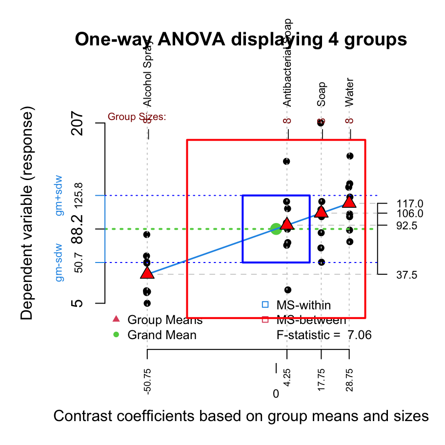

## Graphical ANOVA

```r
hand.anova
```

```
## $grandsum
##     Grandmean        df.bet       df.with        MS.bet       MS.with
##         88.25          3.00         28.00       9960.67       1410.14
##        F.stat        F.prob SS.bet/SS.tot
##          7.06          0.00          0.43
##
## $stats
##                    Size Contrast Coef Wt'd Mean  Mean Trim'd Mean    Var.
## Alcohol Spray         8        -50.75      37.5  37.5       35.50  705.43
## Antibacterial Soap    8          4.25      92.5  92.5       92.67 1760.86
## Soap                  8         17.75     106.0 106.0       98.33 2205.14
## Water                 8         28.75     117.0 117.0      115.33  969.14
##                    St. Dev.
## Alcohol Spray         26.56
## Antibacterial Soap    41.96
## Soap                  46.96
## Water                 31.13
```

## What Next?

- P-value large -> Nothing left to say
- P-value small -> Which means are large and which means are small?
- We can perform a t-test to compare two of them.
- We assumed the standard deviations are all equal.
- Use \(s_p\), for pooled standard deviations.
- Use the Students t-model, df = N - k.
- If we wanted to do a t-test for each pair:
  - P(Type I Error) = 0.05 for each test.
  - Good chance at least one will have a Type I error.
- **Bonferroni to the rescue!**
  - Adjust a to \(\alpha/J\) where J is the number of comparisons.
  - 95% confidence (1 - 0.05) with 3 comparisons adjusts to \((1 - 0.05/3) \approx 0.98333\).
  - Use this adjusted value to find t**.